# Multiple Regression

# The multiple regression model

## Basics

Consider the very first model in the endogeneity section, which has $K = 3$ RHS variables, also known as **covariates** or **regressors**. (written out again, with $e$ becoming $u$.):

$$y = \beta_0 + \beta_1 x_1 + \beta_2 x_2 + u.
\tag{1}$$

Assume we have a sample of data:
$$\{(y_i, x_{1i}, x_{2i}): i=1,\dots,n \}.$$
The question is, how do we estimate this model by OLS? The only difference is that in the endogeneity section we had only two variables, whereas in general we have $K$ variables. Our approach is identical to before, just that $K$ is bigger.

The general principle is that we need as many assumptions like A1, A2, A4 as there are parameters to estimate. As $K=3$, these are
$$\begin{align}
\tag{A1}
E(u) &= 0 \\
\tag{A2}
Cov(u, x_1) &= 0 \\
\tag{A3}
Cov(u, x_2) &= 0.
\end{align}$$

Next, we multiply Equation 1 by 1, $x_1$ and $x_2$ respectively:
$$\begin{align*}
y &= \beta_0 + \beta_1 x_1 + \beta_2 x_2 + u \\
y x_1 &= \beta_0 x_1 + \beta_1 x^2_1 + \beta_2 x_2x_1 + ux_1 \\
y x_2 &= \beta_0 x_2 + \beta_1 x_1x_2 + \beta_2 x^2_2 + ux_2
\end{align*}$$
and apply the expectation operator $E(.)$ throughout:
$$\begin{align*}
E(y ) &= \beta_0 + \beta_1 E(x_1 ) + \beta_2 E(x_2 ) + E(u ) \\
E(y x_1) &= \beta_0 E(x_1) + \beta_1 E(x^2_1 ) + \beta_2 E(x_2 x_1) + E(u x_1) \\
E(y x_2) &= \beta_0 E(x_2) + \beta_1 E(x_1 x_2) + \beta_2 E(x^2_2 ) + E(u x_2).
\end{align*}$$

Next, we impose A1, A2, A3 above (Remember, $Cov(u, x_k) = 0$ and $E(u x_k) = 0$ are the same thing):
$$E(y ) = \beta_0 + \beta_1 E(x_1 ) + \beta_2 E(x_2 ) + 0
\tag{2}$$
$$E(y x_1) = \beta_0 E(x_1) + \beta_1 E(x^2_1 ) + \beta_2 E(x_2 x_1) + 0
\tag{3}$$
$$E(y x_2) = \beta_0 E(x_2) + \beta_1 E(x_1 x_2) + \beta_2 E(x^2_2 ) + 0.
\tag{4}$$

These are 3 equations for 3 unknown $\beta$s. Assuming they can be solved, they generate the $\hat{\beta_0}$ $\hat{\beta_1}$ and $\hat{\beta_2}$. The estimators are said to be identified.

Next, we replace population means, variances, and covariances by their sample counterparts (the analogy principle). Finally, the system of equations is solved:
$$\Sigma y_i = \hat{\beta_0} + \hat{\beta}_1 \Sigma x_{1i} + \hat{\beta_2} \Sigma x_{2i}
\tag{5}$$

$$\Sigma y_i x_{1i} = \hat{\beta_0} \Sigma x_{1i} + \hat{\beta}_1 \Sigma x^2_{1i} + \hat{\beta_2} \Sigma x_{2i} x_{1i}
\tag{6}$$

$$\Sigma y_i x_{2i} = \hat{\beta_0} \Sigma x_{2i} + \hat{\beta}_1 \Sigma x_{1i} x_{2i} + \hat{\beta_2} \Sigma x^2_{2i}.
\tag{7}$$

As the computer knows what to do, there is no need to write down the solution in a course like Econ20222.This happens in more technical courses. Similarly, the computer knows what to do when calculating the robust standard errors for $\hat{\beta_0}$ $\hat{\beta_1}$ and $\hat{\beta_2}$. This is essentially what OLS in a multiple regression context is.

There are situations when the computer will not be able to solve the system of Equation 5, Equation 6,and Equation 7. They are:

1. When any of the $x_{ki}$ do not have any variation in the sample:

   $$\widehat{Var(x_{ki})} = 0.$$

   Recall that this was an issue in the $K = 2$ case.
2. When there is an exact linear combination between the $x_{ki}$’s:

   $$\lambda_1 x_{1i} + \lambda_2 x_{2i} = \lambda_0.$$

   This is known as **perfect multicollinearity**. It can happen a lot.
   Examples:
   $$\begin{align}
   \tag{R1}
   x_{1i} &= -\lambda_2 x_{2i} \quad (\lambda_1 = 1, \lambda_0 = 0).\\
   \tag{R2}
   x_{1i} + x_{2i} &= 1 \quad (\lambda_1 = \lambda_2 = \lambda_0 = 1).
   \end{align}$$

   What does the investigator then do? If (R1) is the problem, then either $x_{1i}$ or $x_{2i}$ has to be “dropped” from the model; there is no new information in $x_{1i}$ that is not already in $x_{2i}$. In general, one needs to impose the offending **restriction** on the model. So, for (R2), substitute into Equation 1 and collect terms:

   $$y = (\beta_0 + \beta_2) + (\beta_1 - \beta_2) x_1 + u.$$

   One can see that $\beta_2$ is not identified and can be dropped, ignored, or set to zero. This is because $x_1$ and $x_2$ are the same as each other (via (R2)).

This multiple regression technique extends to $K>3$. Again, the computer knows what to do.

Equation 2 , Equation 3 Equation 4 becomes:
$$\begin{align*}
E(y) &= \beta_0 + \beta_1 E(x_1) \\
E(y x_1) &= \beta_0 E(x_1) + \beta_1 E(x^2_1).
\end{align*}$$

Now, multiply the first equation by $E(x_1)$ and subtract from the second:
$$\begin{align*}
E(y x_1) - E(y)E(x_1) &= \beta_1 \{E(x^2_1)-[E(x_1)]^2\} \quad \text{or}\\
Cov(y,x_1) &= \beta_1 Var(x_1),
\end{align*}$$
which takes us back to Equation
$$\beta = \frac{cov(y,x)}{var(x)}$$
in the introduction section.

**TipPractice Questions : GPA and Time Allocation**

In a study relating college grade point average (GPA) to time spent in various activities. You distribute a survey to several students. Students are asked how many hours they spend each week in four activities: studying, sleeping, working, and leisure. Any activity is put into one of the four categories, so that for each student: $study + sleep + work + leisure = 168$ Consider the following model,

$$GPA = \beta_0 + \beta_1 study + \beta_2 sleep + \beta_3 work + \beta_4 leisure + u.$$
1. Holding sleep, work, and leisure fixed, increasing study by one additional hour will increase GPA by $\beta_1$ units.

2.Why can the computer not estimate this model using OLS as written?

GPA is not measured correctly The sample size is too small One of the regressors has zero variance There is perfect multicollinearity among the regressors

3. If we solve for $leisure = 168 - study - sleep - work$ and substitute this into the model, which expression is correct?

$GPA = (\beta_0 - \beta_4) + \beta_1 study + \beta_2 sleep + \beta_3 work + u$ $GPA = \beta_0 + \beta_1 study + \beta_2 sleep + \beta_3 work + u$ $GPA = 168 + \beta_1 study + u$ $GPA = (\beta_0 + 168\beta_4) + (\beta_1 - \beta_4)study + (\beta_2 - \beta_4)sleep + (\beta_3 - \beta_4)work + u$

In the rest of this section, we examine various uses for the multiple regression model.

## More than two categories; firm-size and wages

It is well-known that larger firms pay higher wages than smaller firms. This is actually true on many observable variables (gender, education, industry, occupation, etc), but for the moment let us think about the raw relationship between wages and firm-size.

The data at hand ask employees to record their firm size, say $f_i^*$ (an integer), into one of $K = 9$ **bins** (or **bands** or **buckets**)(The notation $x \in (a,b]$ is the same as $a < x \le b$):

$$[1,2],\;[3,9],\;[10,24],\;[25,49],\;[50,99],\;[100,199],\;[200,499],\;[500,999],\;[1000,\infty].$$

Also, this is similar to when we had a dummy variable for men in the introduction section, except that now we have $K$ categories rather than just 2 (men and women). This suggests we “create” $K=9$ dummies variables, defined as follows:
$$\begin{align*}
x_{1i } &=
\begin{cases}
\text{1 if $1 \leq f^*_i \leq 2$} \\
\text{0 else}
\end{cases} \qquad \text{or} \qquad x_{1i}=1(1 \leq f^*_i \leq 2) \\
x_{2i} &=
\begin{cases}
\text{1 if $3 \leq f^*_i \leq 9$} \\
\text{0 else}
\end{cases} \qquad \text{or} \qquad x_{2i}=1(3 \leq f^*_i \leq 9) \\
\vdots \\
x_{9i} &=
\begin{cases}
\text{1 if $f^*_i \geq 1000$} \\
\text{0 else}
\end{cases} \qquad \text{or} \qquad x_{9i}=1(f^*_i \geq 1000 ).
\end{align*}$$

In general, $x = 1$(“condition”) means $x = 1$ if “condition” is true and $x = 0$ if “condition” is false. It is a very neat notation for defining a dummy variable.

The following table should help visualise the data:

[output not shown]

To be clear, individual $n_1+2$ works in a firm who employs 6 other individuals. The data only record that she works in a small firm: between 3 and 9 workers. Her log-pay is 4.86.

In words, $\beta_0$ is average log real hourly wage for the **omitted or base** category (working for a firm employing 1000+ workers). All the other $\beta_k$s are interpreted as the population raw differential in log real hourly wages between the firm-size category that $\beta_k$ “belongs to” and the largest firm-size category. These are estimated by the corresponding raw differentials and are measured in log-points.

The fitted values from this regression are
$$E (\log y | k=j) \quad j=1,\dots,9.$$
In words, there are just 9 fitted values, depending on which firm-size category the individual belongs to. But typically with microeconometric data there are many thousands of datapoints. So one can think of regression as “collapsing” such micro-data to just 9 just data-points:
$$\{(\overline{\log y}_k, f_k): \quad k=1,\dots,9 \}.$$

The final issue whether this relationship can be modelled parametrically? One might want to fit a log-log model:
$$\log y_k = \delta_0 + \delta_1 \log f_k + \text{error}_k \qquad k=1,\dots,9.$$
or a quadratic
$$\log y_k = \delta_0 + \delta_1 f_k + \delta_2 f^2_k + \text{error}_k \qquad k=1,\dots,9.$$
The relationship between log-pay and age is often modelled like this. This is discussed next.

## Controlling for observables

The basic idea is that we add as many relevant variables as we can to a model, to mitigate/minimise of the effect of omitted variables bias (OVB). OVB was discussed in the enogeneity section. But we emphasise that there is often something fundamentally unobserved. If so, adding controls will not completely remove OVB.

Consider the multiple regression model:
$$\begin{aligned}
y &= \beta_0 + \beta_1 x_1 + \beta_2 x_2 + \dots + \beta_K x_K + u \\
&= \beta_0 + \beta_1 x_1 + \mathbf{x}'\mathbf{b} + u
\end{aligned}$$
$\beta_1$ is the effect of interest. All the other variables are **controls**. The second line introduces some useful notation:
$$\mathbf{x}' = (x_2, \dots, x_K) \quad
\mathbf{b}' = (\beta_2, \dots, \beta_K).$$
If you uncomfortable with the idea of multiplying vectors, just think $\mathbf{x}'\mathbf{b}$ as short-hand which saves the clumisnes of writing out the long list $\beta_2 x_2 + \dots + \beta_K x_K$.

Often $x_1$ is a dummy $d$ (sometimes a treatment or policy dummy).

**NoteExample Lifetime earnings and a university degree**

Consider the model:
$$y = \beta_0 + \tau d + \beta_1 a + \beta_2 a^2 + \mathbf{x}'\mathbf{b} + u
\tag{9}$$
where $y$ is earnings, $d$ is a graduate dummy, and $a$ is age.

Our objective is to interpret the key parameters (assuming all the RHS variables are exogenous). We do the usual trick of switching $d$ on-and-off:
$$\begin{align*}
E(y | a,\mathbf{x}',d=1) &= \beta_0 + \tau + \beta_1 a + \beta_2 a^2 + \mathbf{x}'\mathbf{b} \\
E(y | a,\mathbf{x}',d=0) &= \beta_0 \hspace{7.6mm} + \beta_1 a + \beta_2 a^2 + \mathbf{x}'\mathbf{b}.
\end{align*}$$
Subtracting provides an interpretation for the parameter $\tau$ associated with the graduate dummy (Notice the usefulness of the $\mathbf{x}$ notation. Without it, we would have to write $E(y | a,x_2, \dots, x_K,d=0)$.),
$$\tau = E(y | a,\mathbf{x}',d=1)-E(y | a,\mathbf{x}',d=0),$$
which is the so-called **conditional differential** (or conditional treatment effect, if appropriate.) This is contrasted with the **unconditional differential**
$$E(y | d=1)-E(y | d=0),
\tag{10}$$
which was first discussed in the introduction earlier. The difference between the conditional and unconditional differential is the presence of $\{a,a^2,\mathbf{x}'\}$ in Equation~Equation 9.

The expression $E(y | a,\mathbf{x}',d)$ is a so-called **Conditional Expectation Function** (CEF). In this set-up there are actually two of them, for graduates and non-graduates respectively. Both CEFs depend on $\{a,a^2,\mathbf{x}'\}$, whereas their difference, $\tau$, does not. It is a single number that captures the gap between average $y$ for both groups. This is because everything comes from the same regression, Equation 9, and so everything nets out, especially $\beta_1 a + \beta_2 a^2$. In other words, the two CEFs are parallel when plotted in the same picture: Figure 1 plots the estimated relationship between (unlogged) annual pay and age for for graduates and non-graduates, but for males only.(Note:One always models gender separately. Although the pattern for women is similar, not drawn, retirement is at 60, not 65, and annual pay is much lower on average.)

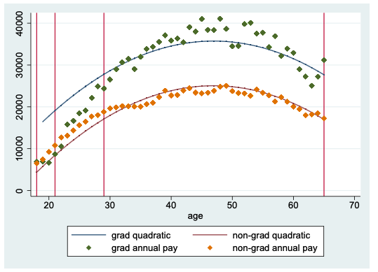

In passing, when plotting the CEFs, what do we do about the term $\mathbf{x}'\mathbf{b}$? When the model has been estimated, we have $\hat{\beta_k}$s, but what do we do about the $x_i$s, which vary from observation to observation? The answer is to use sample averages
$$\mathbf{x}'\mathbf{\hat{b}} = \hat{\beta_2} \bar{x}_2 + \dots + \hat{\beta_K} \bar{x}_K.$$
In the software, this can be pain.

The results are given in Table 1 (Figure 2). Column~(1) reports the raw gradaute differential, whereas Column~(2) reports the estimated from Equation 9. From the latter, one can see that $\hat{\tau}$ is about £ 10.7k, which is can be converted into a lifetime figure by multiplying £10.7k by 65-21=44 years.

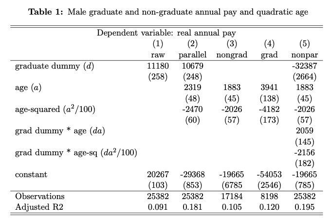

Figure 2

*Notes:*  
(a) Robust standard errors in parentheses.  
(b) Data are from the BHPS/US extract discussed elsewhere.  
(c) Column (5) reports estimates of Equation Equation 11.  
(d) Columns (3) and (4) are identical to Column (5), seen by switching the graduate dummy on and off.

But surely the next figure is even more realistic ?

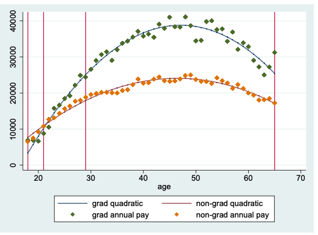

Figure 3: See previous figure, except that this plots Column~(5), Table 1

Now the gap is no longer a constant, but actually a quadratic in age. In other words, we need to make the age-relationship vary by $d$. To do this, we add two , $da$ and $da^2$, to the model:
$$y = \beta_0 + \beta_1 a + \beta_2 a^2 + \tau_0 d + \tau_1 da
+ \tau_2 da^2 + \mathbf{x}'\mathbf{b} + u.
\tag{11}$$
This is basic estimating equation used in a recent IFS Working Paper.(See [IFS publication 13731](https://www.ifs.org.uk/publications/13731).)

## Long and short regressions

Angrist & Pischke (2015) use the long/short terminology. Define $\hat{\beta}_1$ as the OLS estimate from the long regression and $\tilde{\beta}_1$ as the OLS estimate from the short regression. When the long regression contains one extra covariate, we compare the estimates from:
$$\begin{align*}
\tag{L}
y &= \beta_0 + \beta_1 x_1 + \beta_2 x_2 + e \\
\tag{S}
y &= \beta_0 + \beta_1 x_1 + u,
\end{align*}$$
with $Cov(e,x_1)= Cov(e,x_2)=E(e)=0$. When estimating (S), the OVB formula
$$\text{Bias}(\hat{\beta_1}) \equiv E(\hat{\beta_1}) - \beta_1 =
\beta_2 \frac{Cov(x_2,x_1)}{Var(x_1)}= \beta_2 \delta_1$$
in the endogeneity section says:

$$\text{Bias}(\tilde{\beta_1}) \equiv E(\tilde{\beta_1}) - \beta_1 =
\beta_2 \frac{Cov(x_2,x_1)}{Var(x_1)}= \beta_2 \delta_1,
\tag{12}$$

where $\delta_1$ is the “slope” parameter in population model that relates $x_1$ and $x_2$:
$$x_2 = \delta_0 + \delta_1 x_1 + \text{error}.$$
On the other hand, when estimating (L), the OVB formula says the bias is zero:
$$\text{Bias}(\hat{\beta_1}) \equiv E(\hat{\beta_1}) - \beta_1 =0.
\tag{13}$$

Subtracting Equation 13 from Equation 12, we end up with
$$E(\tilde{\beta_1}) - E(\hat{\beta_1}) = \beta_2 \delta_1.$$
It turns out that this holds in the data:(*Note:*You do not need to know the actual details; see the Appendix to this section.)
$$\tilde{\beta_1} - \hat{\beta_1} = \hat{\beta_2} \hat{\delta}_1.
\tag{14}$$
When the long regression is longer than 2 covariates
$$\tag{L}
y = \beta_0 + \beta_1 x_1 + \beta_2 x_2 + \dots + \beta_K x_K + e,$$
the formula Equation 14 doesn’t hold exactly, but it still works in principle.

The formula is very useful in many situations. Two examples were given in the lectures.

To conclude, the argument is that a correctly specified model completely removes OVB, provided the usual exogeneity assumption(s) hold. It is worth restating exactly what “unbiased” actually means. To quote Wooldridge(2013, pages 87/88):

> Since we are approaching the point where we can use multiple regression in serious empirical work, it is useful to remember the meaning of unbiasedness. It is tempting, in examples such as the wage equation in (3.19), to say something like “9.2% is an unbiased estimate of the return to education.” As we know, an estimate cannot be unbiased: an estimate is a fixed number, obtained from a particular sample, which usually is not equal to the population parameter. When we say that OLS is unbiased under Assumptions MLR.1 through MLR.4 (see footnote[^1]), we mean that the procedure by which the OLS estimates are obtained is unbiased when we view the procedure as being applied across all possible random samples. We hope that we have obtained a sample that gives us an estimate close to the population value, but, unfortunately, this cannot be assured. What is assured is that we have no reason to believe our estimate is more likely to be too big or more likely to be too small.

This is essentially the same as the quotation in Angrist and Pischke (2015) on Page 5.

**TipPractice Questions**

Suppose the true model is
$$y = \beta_0 + \beta_1 x_1 + \beta_2 x_2 + u,$$
but $x_2$ is omitted from the regression. If $\beta_2 < 0$ and $Corr(x_1, x_2) < 0$, what is the bias in $\tilde{\beta}_1$?

Negative bias Positive bias Zero bias Bias cannot be determined

# Appendix

showing that Equation 14 holds

When estimated by OLS, the long and short regressions are written:

$$\begin{aligned}
\text{(L)} \qquad
y &= \hat{\beta}_0 + \hat{\beta}_1 x_1 + \hat{\beta}_2 x_2 + \hat{u}, \\
\text{(S)} \qquad
y &= \tilde{\beta}_0 + \tilde{\beta}_1 x_1 + \tilde{u}.
\end{aligned}$$

The OLS estimator of $\beta_1$ from the short regression is

$$\tilde{\beta}_1 = \frac{\widehat{Cov}(x_1, y)}{\widehat{Var}(x_1)} .$$

Substituting in from the long regression:

$$\begin{aligned}
\tilde{\beta}_1
&= \frac{\widehat{Cov}\!\left(x_1,
\hat{\beta}_0 + \hat{\beta}_1 x_1 + \hat{\beta}_2 x_2 + \hat{u}\right)}
{\widehat{Var}(x_1)} \\[6pt]
&= \frac{0
+ \hat{\beta}_1 \widehat{Cov}(x_1, x_1)
+ \hat{\beta}_2 \widehat{Cov}(x_1, x_2)
+ \widehat{Cov}(x_1, \hat{u})}
{\widehat{Var}(x_1)} .
\end{aligned}$$

Remembering that OLS is defined by imposing $\widehat{Cov}(x_1, \hat{u}) = 0$:

$$\tilde{\beta}_1
= \hat{\beta}_1
+ \hat{\beta}_2 \frac{\widehat{Cov}(x_1, x_2)}{\widehat{Var}(x_1)}
= \hat{\beta}_1 + \hat{\beta}_2 \hat{\delta}_1 ,$$

where $\hat{\delta}_1$ comes from regressing $x_2$ on $x_1$:

$$\text{(qed)} \qquad
\hat{x}_2 = \hat{\delta}_0 + \hat{\delta}_1 x_1 .$$

# Reading

This section is based on both Angrist & Pischke (2015, chapter 2) and Wooldridge (2018, chapter 3).

Angrist, J. & Pischke, J.-S. (2015), Mastering ’Metrics: The Path From Cause To Effect, Princeton University Press, Princeton, NJ.

## Footnotes

[^1]: Wooldridge’s Assumptions MLR.1 through MLR.4 essentially correspond to the two assumptions we make in the introduction section.